# Tugas Individu Analisis Regresi

Sandra Berliana Putri

2024-03-05

# PENANGANAN KONDISI TAK STANDAR DALAM REGRESI

## Pola Garis

```r
library(readxl)
```

```r
library(ggplot2)
data <- read_xlsx("C:/Users/ASUS/Documents/Semester 4/Analisis Regresi/Tugas/Individu/Minggu 7/DataAsumsi.xlsx")

(model <- lm(Y~X, data=data))
```

```
##
## Call:
## lm(formula = Y ~ X, data = data)
##
## Coefficients:
## (Intercept)            X
##     46.4604      -0.7525
```

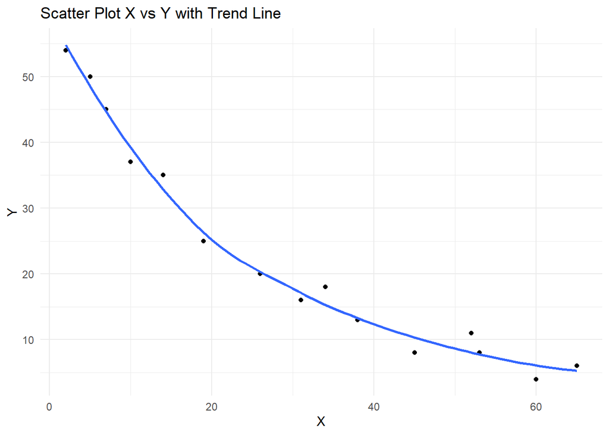

```r
ggplot(data, aes(x = X, y = Y)) +
  geom_point() +
  geom_smooth(method = "loess", se = FALSE) +
  labs(x = "X", y = "Y", title = "Scatter Plot X vs Y with Trend Line") +
  theme_minimal()
```

Dugaan persamaan regresi:
$$Ŷ =46.4604 -
0.7525X_1$$
Berdasarkan scatter plot di atas, didapatkan bahwa pola garisnya adalah pola parabola. Akibat pola garisnya bukan linear maka transformasi perlu dilakukan. Oleh karena
$$𝛃_1<0$$
, maka transformasi dilakukan dengan cara X diperkecil dan Y diperkecil.

## Transformasi Pola Parabola

```r
data$X_transformed <- sqrt(data$X)
data$Y_transformed <- sqrt(data$Y)
```

Proses syntax di atas dilakukan untuk memperkecil X dan Y dengan mengakarkan kedua variabel tersebut.

## Hasil Transformasi menjadi Pola Linear

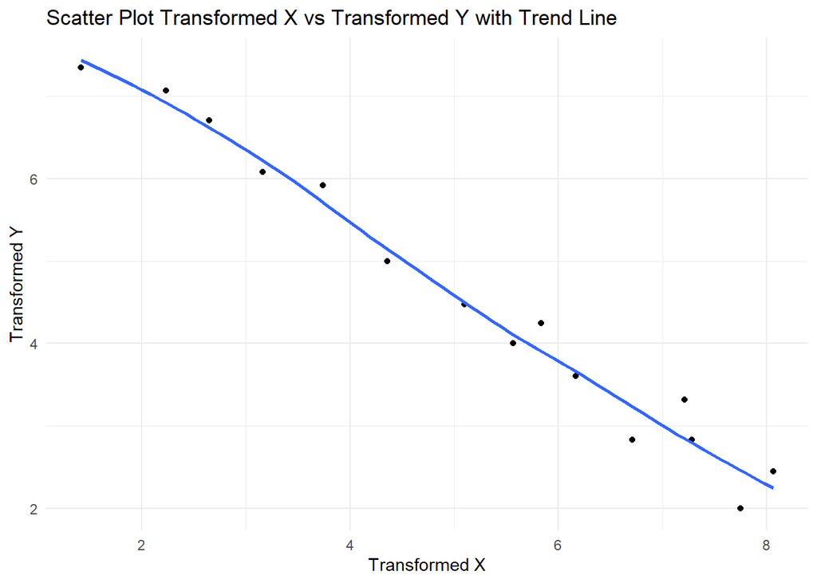

```r
ggplot(data, aes(x = X_transformed, y = Y_transformed)) +
  geom_point() +
  geom_smooth(method = "loess", se = FALSE) +
  labs(x = "Transformed X", y = "Transformed Y", title = "Scatter Plot Transformed X vs Transformed Y with Trend Line") +
  theme_minimal()
```

# Mencari Persamaan Regresi Setelah Transformasi

```r
library(dplyr)
data <- data %>% mutate(X_transformed = sqrt(X))

data <- data %>% mutate(Y_transformed = sqrt(Y))
```

Syntax di atas merupakan proses menambahkan dua kolom baru dengan nama X_transformed dan Y_transformed.

## Persamaan Regresi

```r
(modelbaru <- lm(Y_transformed ~ X_transformed, data=data))
```

```
##
## Call:
## lm(formula = Y_transformed ~ X_transformed, data = data)
##
## Coefficients:
##   (Intercept)  X_transformed
##        8.7125        -0.8134
```

Dugaan persamaan regresi setelah transformasi :
$$Ŷ = 8.71254 -0.81345X_1$$

# Cek Asumsi Persamaan Regresi Hasil Transformasi

## Uji Formal Kondisi Gauss-Markov

### 1. Nilai harapan sisaan sama dengan nol

$$H_0 : µ = 0$$
$$H_1 : µ ≠ 0$$

```r
t.test(modelbaru$residuals,mu = 0,conf.level = 0.95)
```

```
##
##  One Sample t-test
##
## data:  modelbaru$residuals
## t = 2.0334e-16, df = 14, p-value = 1
## alternative hypothesis: true mean is not equal to 0
## 95 percent confidence interval:
##  -0.1463783  0.1463783
## sample estimates:
##    mean of x
## 1.387779e-17
```

Dalam selang kepercayaan 95%, p-value > 0.05 sehingga tidak cukup bukti untuk menolak H_0. Artinya,nilai harapan sisaan sama dengan nol.

### 2. Ragam sisaan homogen

$$H_0 : \text {homogen}$$
$$H_1 : \text {tidak homogen}$$

```r
cek.homogen = lm(formula = abs(modelbaru$residuals) ~ X_transformed,
    data = data)
summary(cek.homogen)
```

```
##
## Call:
## lm(formula = abs(modelbaru$residuals) ~ X_transformed, data = data)
##
## Residuals:
##       Min        1Q    Median        3Q       Max
## -0.239909 -0.077755 -0.003872  0.080472  0.194031
##
## Coefficients:
##               Estimate Std. Error t value Pr(>|t|)
## (Intercept)    0.07996    0.08808   0.908    0.380
## X_transformed  0.02713    0.01589   1.707    0.112
##
## Residual standard error: 0.1265 on 13 degrees of freedom
## Multiple R-squared:  0.1832, Adjusted R-squared:  0.1203
## F-statistic: 2.915 on 1 and 13 DF,  p-value: 0.1115
```

```r
library(lmtest)
bptest(modelbaru)
```

```
##
##  studentized Breusch-Pagan test
##
## data:  modelbaru
## BP = 3.9621, df = 1, p-value = 0.04654
```

```r
library(car)
ncvTest(modelbaru)
```

```
## Non-constant Variance Score Test
## Variance formula: ~ fitted.values
## Chisquare = 2.160411, Df = 1, p = 0.14161
```

### 3. Sisaan saling bebas

$$H_0 : \text {Saling bebas}$$
$$H_1 : \text {Tidak saling bebas}$$

```r
library(randtests)
runs.test(modelbaru$residuals)
```

```
##
##  Runs Test
##
## data:  modelbaru$residuals
## statistic = 0, runs = 8, n1 = 7, n2 = 7, n = 14, p-value = 1
## alternative hypothesis: nonrandomness
```

Berdasarkan Runs Test, dalam selang kepercayaan 95%, p-value > 0.05 sehingga tidak cukup bukti untuk menolak H_0. Artinya, sisaan saling bebas.

```r
library(lmtest)
dwtest(modelbaru)
```

```
##
##  Durbin-Watson test
##
## data:  modelbaru
## DW = 2.6803, p-value = 0.8629
## alternative hypothesis: true autocorrelation is greater than 0
```

Berdasarkan Durbin-Watson Test, dalam selang kepercayaan 95%, p-value > 0.05 sehingga tidak cukup bukti untuk menolak H_0. Artinya, autokorelasi sama dengan nol.

## Uji Formal Normalitas Sisaan

$$H_0 : \text {Menyebar normal}$$
$$H_1 : \text {Tidak menyebar normal}$$

```r
ks.test(modelbaru$residuals, "pnorm", mean=mean(modelbaru$residuals), sd=sd(modelbaru$residuals))
```

```
##
##  Exact one-sample Kolmogorov-Smirnov test
##
## data:  modelbaru$residuals
## D = 0.11948, p-value = 0.9655
## alternative hypothesis: two-sided
```

```r
library(car)
shapiro.test(modelbaru$residuals)
```

```
##
##  Shapiro-Wilk normality test
##
## data:  modelbaru$residuals
## W = 0.96504, p-value = 0.7791
```

Dalam selang kepercayaan 95%, p-value > 0.05 sehingga tidak cukup bukti untuk menolak H_0. Artinya, galat menyebar normal.